# Reproducible Research: Peer Assessment 1

Created by Brandon Hu on May 17, 2015

## Basic Configurtions

```r
echo = TRUE #Allow to read the code
options(scipen = 1) #Turn off scientific notations for numbers
knitr::opts_chunk$set(fig.width=12, fig.height=8, warning=FALSE, message=FALSE) #Turn off any warning messages and set the figure width and height
```

## Loading and preprocessing the data

```r
unzip("activity.zip") #Unzip the data file
data <- read.csv("activity.csv", colClasses = c("integer", "Date", "factor")) #read the data and cast each column to specific the data type
data$month <- as.numeric(format(data$date, "%m")) # to display data to split into months for ggplot usage later in the code
noNA <- na.omit(data) #create new data set with no NA data
rownames(noNA) <- 1:nrow(noNA) #set the row names
head(noNA) #retrieve the first 6 rows
```

```
##   steps       date interval month
## 1     0 2012-10-02        0    10
## 2     0 2012-10-02        5    10
## 3     0 2012-10-02       10    10
## 4     0 2012-10-02       15    10
## 5     0 2012-10-02       20    10
## 6     0 2012-10-02       25    10
```

```r
dim(noNA) #print out the dimension
```

```
## [1] 15264     4
```

```r
library(ggplot2) #load the ggplot2 package
```

## What is mean total number of steps taken per day?

1. Calculate the total number of steps taken per day

```r
totalSteps <- aggregate(noNA$steps, list(Date = noNA$date), FUN = "sum")$x #sum the total no. of steps and assign to a variable
totalSteps
```

```
##  [1]   126 11352 12116 13294 15420 11015 12811  9900 10304 17382 12426
## [12] 15098 10139 15084 13452 10056 11829 10395  8821 13460  8918  8355
## [23]  2492  6778 10119 11458  5018  9819 15414 10600 10571 10439  8334
## [34] 12883  3219 12608 10765  7336    41  5441 14339 15110  8841  4472
## [45] 12787 20427 21194 14478 11834 11162 13646 10183  7047
```

2. If you do not understand the difference between a histogram and a barplot, research the difference between them. Make a histogram of the total number of steps taken each day

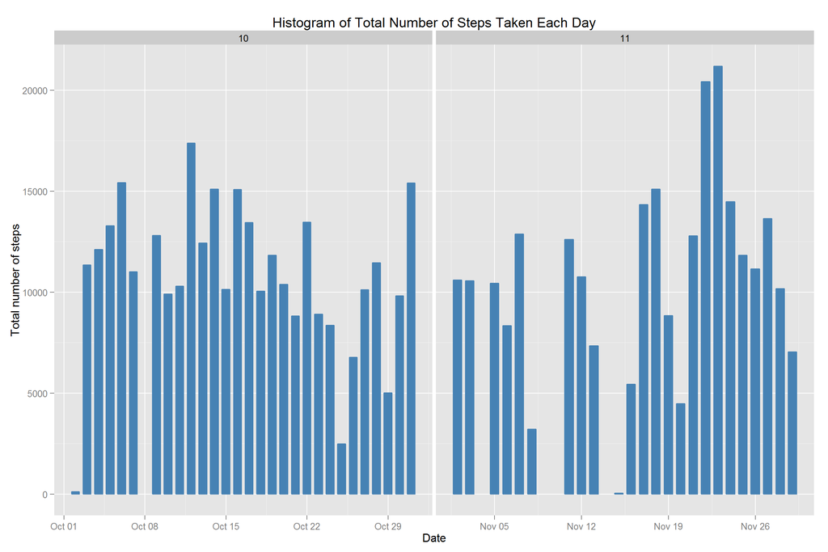

```r
ggplot(noNA, aes(date, steps)) + geom_bar(stat = "identity", colour = "steelblue", fill = "steelblue", width = 0.7) + facet_grid(. ~ month, scales = "free") + labs(title = "Histogram of Total Number of Steps Taken Each Day", x = "Date", y = "Total number of steps")
```

3. Calculate and report the mean and median of the total number of steps taken per day

```r
mean(totalSteps) #mean
```

```
## [1] 10766.19
```

```r
median(totalSteps) #median
```

```
## [1] 10765
```

## What is the average daily activity pattern?

1. Make a time series plot (i.e. type = “l”) of the 5-minute interval (x-axis) and the average number of steps taken, averaged across all days (y-axis)

[figure not shown]

```r
avgSteps <- aggregate(noNA$steps, list(interval = noNA$interval), FUN = "mean")
#avg steps and assign to a variable
names(avgSteps)[2] <- "average_steps" #rename the colname x to average_steps
ggplot(avgSteps, aes(interval, average_steps)) + geom_line(color = "steelblue", size = 0.8) + labs(title = "Time Series Plot of the 5-minute Interval", x = "5-minute intervals", y = "Average Number of Steps Taken")
```

2. Which 5-minute interval, on average across all the days in the dataset, contains the maximum number of steps?

```r
avgSteps[avgSteps$average_steps == max(avgSteps$average_steps),]
```

```
##     interval average_steps
## 272      835      206.1698
```

## Imputing missing values

1. Calculate and report the total number of missing values in the dataset (i.e. the total number of rows with NAs)

```r
sum(is.na(data)) #get the total of the of NAs values in the data
```

```
## [1] 2304
```

2. Devise a strategy for filling in all of the missing values in the dataset. The strategy does not need to be sophisticated. For example, you could use the mean/median for that day, or the mean for that 5-minute interval, etc

My strategy is using the mean for that 5-minute interval to fill in the NA values

3. Create a new dataset that is equal to the original dataset but with the missing data filled in.

```r
newData <- data #clone the data
for (i in 1:nrow(newData))
{
    if (is.na(newData$steps[i]))
    {
        newData$steps[i] <- avgSteps[which(newData$interval[i] == avgSteps$interval), ]$average_steps
    }
}
```

4. Make a histogram of the total number of steps taken each day

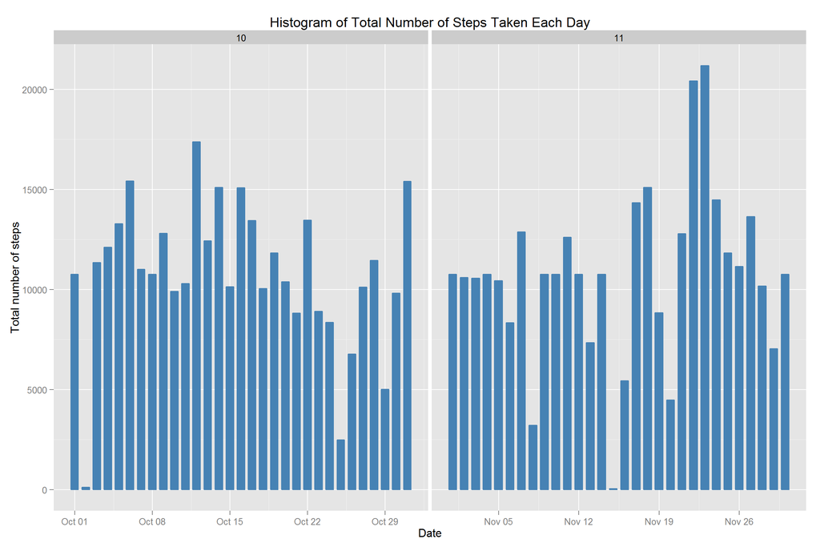

```r
ggplot(newData, aes(date, steps)) + geom_bar(stat = "identity", colour = "steelblue", fill = "steelblue", width = 0.7) + facet_grid(. ~ month, scales = "free") + labs(title = "Histogram of Total Number of Steps Taken Each Day", x = "Date", y = "Total number of steps")
```

- Calculate and report the new mean and median total number of steps taken per day.

```r
#sum the new data, total no. of steps and assign to a variable
newTotalSteps <- aggregate(newData$steps, list(Date = newData$date), FUN = "sum")$x
newMean <- mean(newTotalSteps)
newMedian <- median(newTotalSteps)
```

The following result is the new mean value:

```r
newMean
```

```
## [1] 10766.19
```

The following result is the new median value:

```r
newMedian
```

```
## [1] 10766.19
```

- Compute these values differ from the estimates from the first part of the assignment

```r
oldMean <- mean(totalSteps) #old mean
oldMedian <- median(totalSteps) #median
newMean - oldMean
```

```
## [1] 0
```

```r
newMedian - oldMedian
```

```
## [1] 1.188679
```

- What is the impact of imputing missing data on the estimates of the total daily number of steps?

From the above results, the following conclusion is drawn: There is no impact to imputing missing data on mean value as the old mean equates to the new mean. However, the new median of total daily number of steps is greater than the old median.

## Are there differences in activity patterns between weekdays and weekends?

- Create a new factor variable in the datasets with 2 levels to indicate either is weekday or weekend

```r
newData$day <- factor(format(newData$date, "%A")) #format into full weekday name in the current locale
levels(newData$day) <- list(weekday = c("Monday", "Tuesday",
                                             "Wednesday",
                                             "Thursday", "Friday"),
                                 weekend = c("Saturday", "Sunday")) #replace the 'day' column into weekday and weekend instead of showing e.g. Monday.
table(newData$day)
```

```
##
## weekday weekend
##   12960    4608
```

- Make a panel plot containing a time series plot (i.e. type = “l”) of the 5-minute interval (x-axis) and the average number of steps taken, averaged across all weekday days or weekend days (y-axis)

```r
avgSteps <- aggregate(newData$steps, list(interval = newData$interval, days = newData$day), FUN = "mean")
avgSteps
```

[output not shown]

[output cut: 562 more lines]

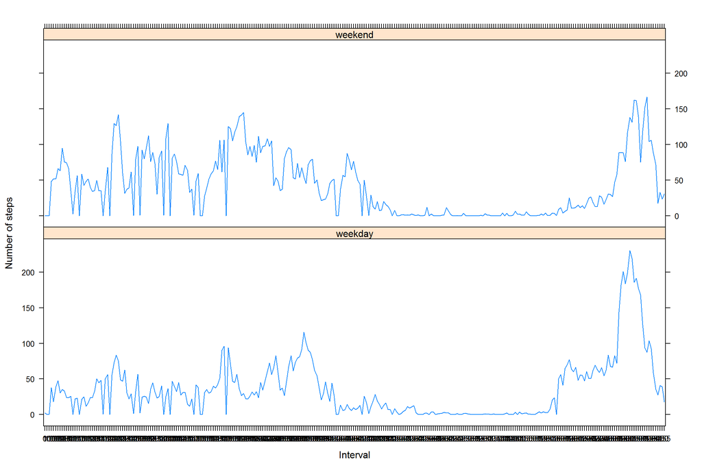

```r
#avg steps and assign to a variable
names(avgSteps)[3] <- "average_steps" #rename the colname x to average_steps
library(lattice) #to plot the panel plot
xyplot(avgSteps$average_steps ~ avgSteps$interval | avgSteps$days,
       layout = c(1, 2), type = "l",
       xlab = "Interval", ylab = "Number of steps")
```